# R - Assignment RMD Basic

Sanchit Vijay

09/20/2022

```r
# 1. Answer each question using in words/paragraph.
# 2. DO NOT use comments inside code blocks (like here) to answer anything. Those are for notes between coders/self. They
# will be ignored, and not counted as answers.
# 3. Keep the line/option    knitr::opts_chunk$set(warning = F, results = "hide", message = F)
# You can temporarily turn this on/off and use other option while you are working on the homework if it helps.
# The submitted work should have this option selected instead.
# 4. All charts/graphs/tables should have appropriate captions.
```

# HW - Module 2 week 03

## Question 1. Import

**Read in the file with all the baseball players height, weight and age info (BaseballHeightWeight.csv) as a dataframe and save it as baseball. Then display the structure of the dataframe.**

```r
# This is coder's comments
# Since my RMD and csv files are in the same working directory, I do not need to give the full path to the csv file. Alternatively, you can use the functions getwd() and setwd() to handle it.

baseball <- data.frame(read.csv("BaseballHeightWeight.csv"))
# baseballdf <- read.csv("BaseballHeightWeight.csv")
# You can compare the two above lines, and look at the object called baseball in the "Environment" on the upper right.
# Turns out either method gives the same result. In some cases (depending on the .csv file), they might differ. To be safe, I usually use data.frame( ) afterwards.
```

The function `read.csv()` was used to load the dataframe. In addition, we can see that there are 1034 in the dataframe. Note that `read.csv()` is just one of the many functions you can use to import data files.

```r
# need results="asis" to overwrite the default, and show the result block in Html/pdf
str(baseball)
```

[output not shown]

I have yet to find a simple and easy way to “pretty-print” such structure in R output. Most of the time we don’t need to show these to the readers though.

## Question 2. Head and Tail

**Print out the first 5 and the last 3 rows of the dataframe.**

The `head()` and `tail()` functions are what we need.

```r
head(baseball, n=5)
```

```
##              Name Team      Position Height.inches. Weight.pounds.  Age
## 1   Adam_Donachie  BAL       Catcher             74            180 23.0
## 2       Paul_Bako  BAL       Catcher             74            215 34.7
## 3 Ramon_Hernandez  BAL       Catcher             72            210 30.8
## 4    Kevin_Millar  BAL First_Baseman             72            210 35.4
## 5     Chris_Gomez  BAL First_Baseman             73            188 35.7
```

```r
tail(baseball, n=3)
```

```
##                Name Team       Position Height.inches. Weight.pounds.  Age
## 1032 Chris_Narveson  STL Relief_Pitcher             75            205 25.2
## 1033  Randy_Keisler  STL Relief_Pitcher             75            190 31.0
## 1034    Josh_Kinney  STL Relief_Pitcher             73            195 27.9
```

But we should use the modified version in `ezids` from now on:

```r
# you can use "markup" or "asis" here to get the same result.
xkabledplyhead(baseball, 5, "The first 5 rows using `xkabledplyhead` function." )
```

The first 5 rows using `xkabledplyhead` function.

| Name | Team | Position | Height.inches. | Weight.pounds. | Age |
| --- | --- | --- | --- | --- | --- |
| Adam_Donachie | BAL | Catcher | 74 | 180 | 23.0 |
| Paul_Bako | BAL | Catcher | 74 | 215 | 34.7 |
| Ramon_Hernandez | BAL | Catcher | 72 | 210 | 30.8 |
| Kevin_Millar | BAL | First_Baseman | 72 | 210 | 35.4 |
| Chris_Gomez | BAL | First_Baseman | 73 | 188 | 35.7 |

and the last three rows:

```r
# you can use "markup" or "asis" here to get the same result.
xkabledplytail(baseball, 3, "The last 3 rows using `xkabledplytail` function." )
```

The last 3 rows using `xkabledplytail` function.

|  | Name | Team | Position | Height.inches. | Weight.pounds. | Age |
| --- | --- | --- | --- | --- | --- | --- |
| 1032 | Chris_Narveson | STL | Relief_Pitcher | 75 | 205 | 25.2 |
| 1033 | Randy_Keisler | STL | Relief_Pitcher | 75 | 190 | 31.0 |
| 1034 | Josh_Kinney | STL | Relief_Pitcher | 73 | 195 | 27.9 |

## Question 3. Header change

**Change the headers/column names from Weight.pounds. to weight, from Height.inches. to height, and Age to age.**

```r
colnames(baseball)[4] <- "height"
colnames(baseball)[5] <- "weight"
colnames(baseball)[6] <- "age"
```

## Question 4. Head again

**Print out the first two lines again to see the new column names.**

```r
xkabledplyhead(baseball, 5)
```

[output not shown]

## Question 5. Summary

**Find the statistics (summary) of the heights, weights, and ages of the players. Using complete sentences, give the reader these summary.**

```r
print("Statistics of height of players")
```

[1] “Statistics of height of players”

```r
summary(baseball$height)
```

Min. 1st Qu. Median Mean 3rd Qu. Max. 67.0 72.0 74.0 73.7 75.0 83.0

```r
print("Statistics of weight of players")
```

[1] “Statistics of weight of players”

```r
summary(baseball$weight)
```

Min. 1st Qu. Median Mean 3rd Qu. Max. NA’s 150 187 200 202 215 290 1

```r
print("Statistics of age of players")
```

[1] “Statistics of age of players”

```r
summary(baseball$age)
```

Min. 1st Qu. Median Mean 3rd Qu. Max. 20.9 25.4 27.9 28.7 31.2 48.5

## Question 6. Subset

**You should find an issue with the weight data with an NA value. Use the `subset( )` function, select that data point (save as shyboy) and find out who the shy boy was.**

```r
shyboy <- subset(baseball, is.na(baseball$weight))
shyboy
```

```
         Name Team         Position height weight  age
```

641 Kirk_Saarloos CIN Starting_Pitcher 72 NA 27.8

```r
cat("Shy boy is ", shyboy$Name)
```

Shy boy is Kirk_Saarloos

## Question 7. Remove Shyboy

**Remove shyboy from baseball, and then show the number of observations of the cleaned up dataframe baseball.**

```r
df_new <- subset(baseball, Name != "Kirk_Saarloos")
cat("Number of observations in new dataframe: ", nrow(df_new))
```

[output not shown]

## Question 8. Boxplot

**Make a quick boxplot of the weight of the players. Use the `title( )` function immediately to add a title to the chart. (Try color #0000FF for blue.)**

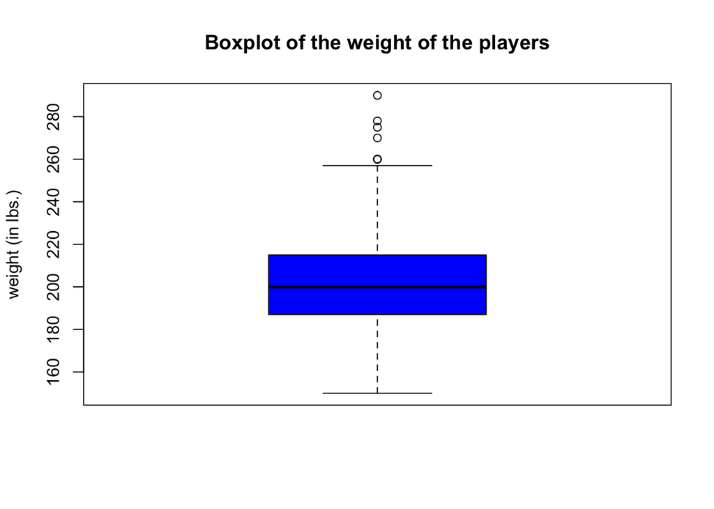

```r
boxplot(df_new$weight, ylab="weight (in lbs.)", col="#0000FF")
title("Boxplot of the weight of the players")
```

## Question 9. Histogram

**Make a histogram of the weight of the players. Try color ‘green’ this time. The function understands the word ‘green’ just fine. Give it a better title than the default. Does the distribution looks normal?**

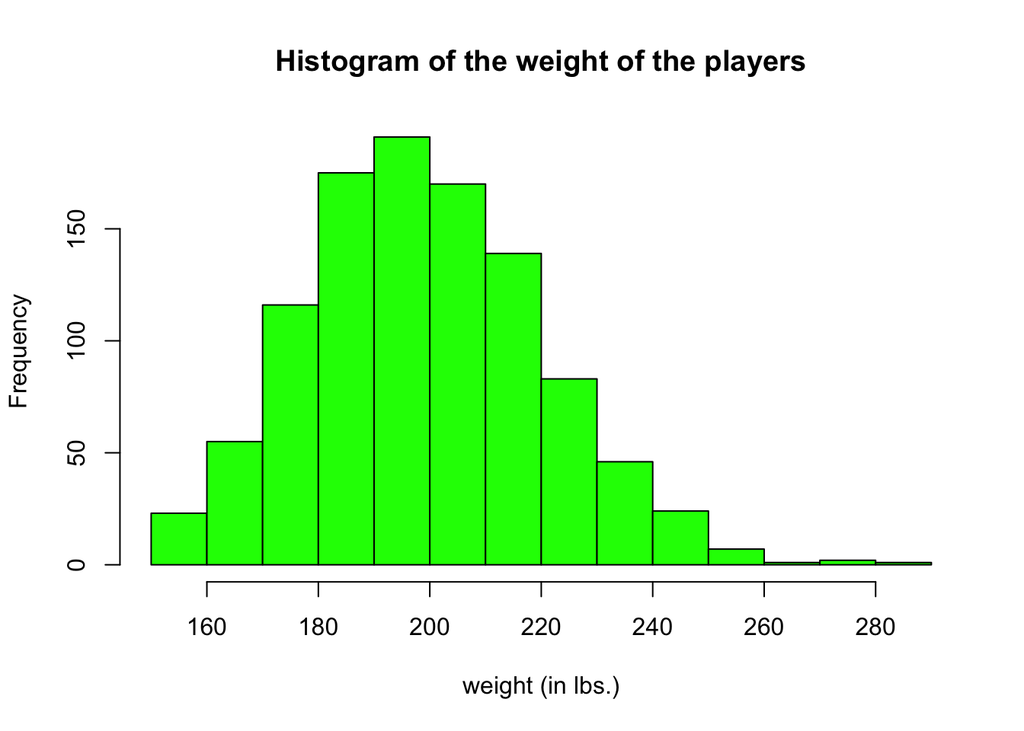

```r
hist(df_new$weight, col="green", main = "Histogram of the weight of the players", xlab = "weight (in lbs.)")
```

```r
cat("Distribution is not normal, it is right-skewed.")
```

Distribution is not normal, it is right-skewed.

## Question 10. Scatterplot

**Use ggplot, make a plot with weights vs heights of the players, color by Teams. Give it an appropriate title.**

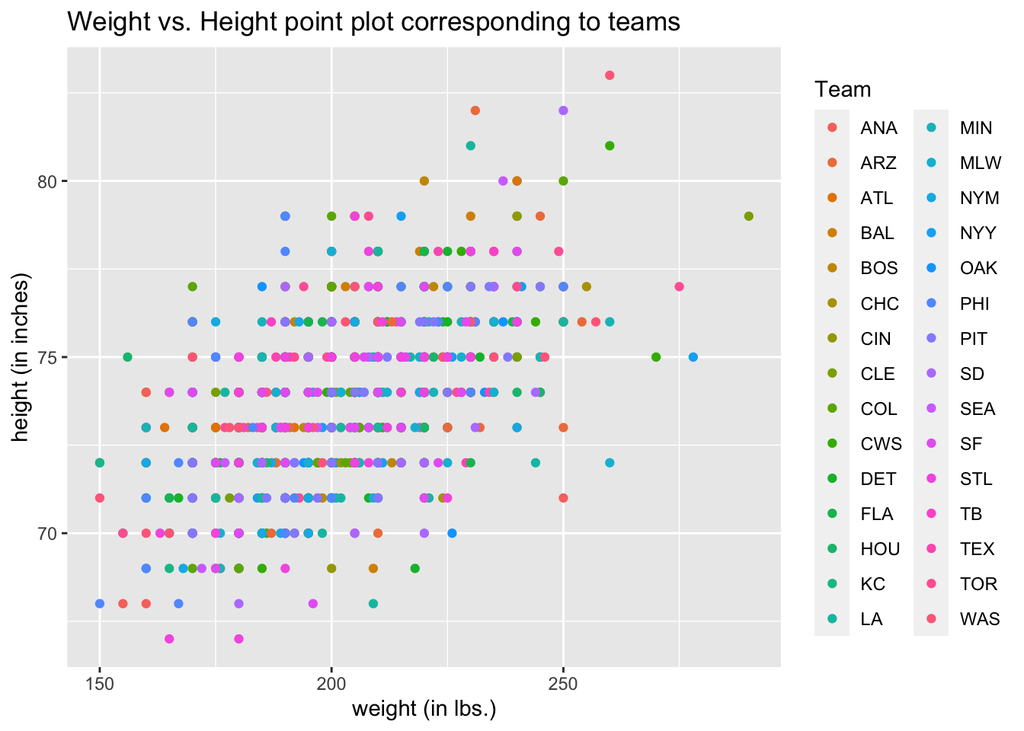

```r
library(ggplot2)
ggplot(df_new, aes(x=weight, y=height, color=Team)) +
  geom_point() +
  labs(x="weight (in lbs.)", y="height (in inches)") +
  labs(title = "Weight vs. Height point plot corresponding to teams")
```

## Question 11. Plot by age

**Make a plot with weights vs heights of the players, color by age.**

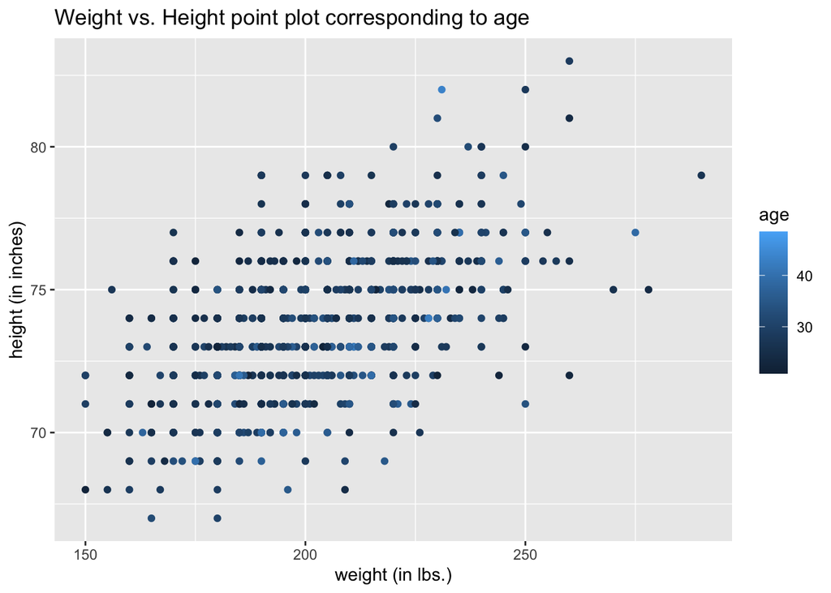

```r
ggplot(df_new, aes(x=weight, y=height)) +
  geom_point(aes(color=age)) +
  labs(x="weight (in lbs.)", y="height (in inches)") +
  labs(title = "Weight vs. Height point plot corresponding to age")
```

## Question 12. Team Washington

**Obtain a subset of the data with only Team Washington. Using complete sentences, give the number of players in Team Washington.**

```r
df_wash <- subset(df_new, Team=="WAS")
cat("Number of players in Team Washington is: ",nrow(df_wash))
```

Number of players in Team Washington is: 36

## Question 13. Old Team Washington

**Obtain another subset with Team Washington and only players older than 28. How many are there in this veteran group?**

```r
df_age_older28 <- subset(df_wash, age>28)
cat("Players with age above 28: ",nrow(df_age_older28))
```

Players with age above 28: 14